# vets() - Vector ETS

Ivan Svetunkov

2025-02-03

This vignette covers `vets()` function, which is a part of legion package. In this vignette we will use data from `Mcomp` package, so it is advised to install it.

Let’s load the necessary packages:

```r
require(legion)
```

```r
Y <- ts(cbind(1000+0.5*c(1:100)+rnorm(100,0,10),
              cbind(1000+1.5*c(1:100)+rnorm(100,0,10))),
        frequency=12);
```

`vets()` function implements Vector ETS from Svetunkov, Chen, and Boylan (2021). This is a model that introduces two dimensional taxonomy: the original ETS one from Hyndman et al. (2008) and the extended for the restrictions on Parameters, Initials and Components (PIC) of the model. By default the function makes smoothing and dampening parameters common between different products and forces a common seasonal initials, resulting in ETS-PIC(LTSD,S,N):

```r
vetsModel <- vets(Y, "MMdM", h=18, holdout=TRUE, silent=FALSE)
```

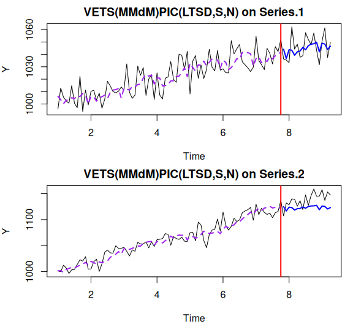

```r
vetsModel <- auto.vets(Y, "PPP", h=18, holdout=TRUE, silent=FALSE)
```

```
## Selecting the best unrestricted model...
## Initial model is VETS(MMN), AICc is: 1256.223
## Testing initials restrictions... 100 %
## Initials restrictions model is (t), AICc is: 1252.318
## Testing parameters restrictions... 14 %29 %43 %57 %71 %86 %100 %
## Parameters restrictions model is (t), AICc is: 1252.185
## Testing components restrictions... 100 %
## Components restrictions model is (none), AICc is: 1252.185
```

`model="PPP"` tells function to select the best between pure additive and pure multiplicative models. This parameter also accepts `model="XXX"`, selecting between pure additive and `model="YYY"`, selecting between pure multiplicative models. Note that if you want to impose restrictions on the initials and components, then pure multiplicative models typically make more sense, aligning with the idea of percentage change of value, rather than the change in the units of data (as in additive models).

Some methods to consider when working with `vets()`:

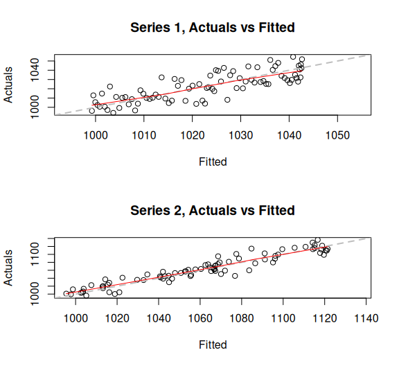

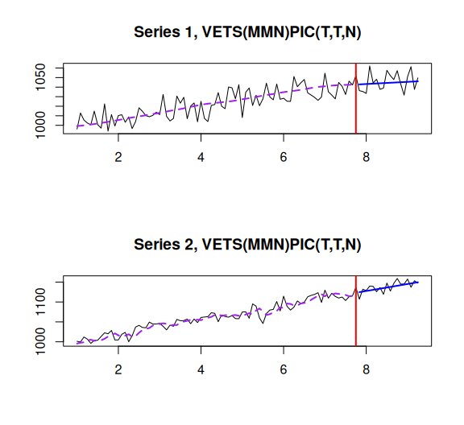

```r
oldpar <- par(mfcol=c(2,1))
plot(vetsModel,1)
plot(vetsModel,7)
par(oldpar)
```

```r
modelType(vetsModel)
```

```
## [1] "MMN"
```

```r
modelType(vetsModel,pic=TRUE)
```

```
## [1] "T,T,N"
```

```r
actuals(vetsModel)
fitted(vetsModel)
residuals(vetsModel)
```

The forecasts can be produced using `forecast()` method:

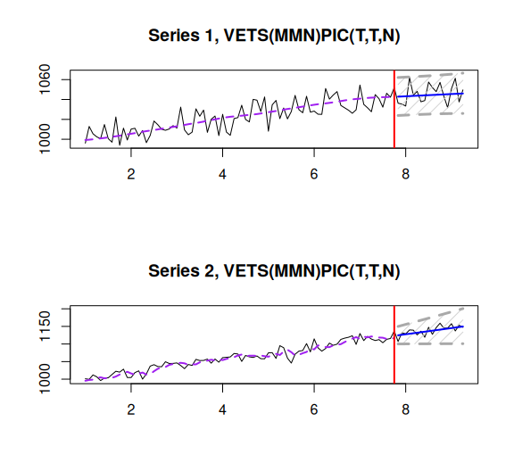

```r
vetsForecast <- forecast(vetsModel, h=18, interval="prediction")
oldpar <- par(mfcol=c(2,1))
plot(vetsForecast)
par(oldpar)
```

The detailed explanation of the underlying model and possible restrictions are provided in Svetunkov, Chen, and Boylan (2021).

### References

Hyndman, Rob J, Anne B Koehler, J Keith Ord, and Ralph D Snyder. 2008. *Forecasting with Exponential Smoothing*. Springer Berlin Heidelberg.

Svetunkov, Ivan., H. Chen, and John E. Boylan. 2021. “A New Taxonomy for Vector Exponential Smoothing and Its Application to Seasonal Time Series.” Department of Management Science, Lancaster University.